# Understanding indexing and coords in pymc

The following is intended as a reminder for myself as to how indexing works in pymc, so that I will index correctly in the future.

Imaging that we were interested in the behaviour in two species of bear. We might observe some attribute for each bear we see:

```python
import numpy as np
import polars as pl

observation = np.array([0.1, 0.8, 0.9, 0.5, 0.1, 0.2, 0.7, 0.1])
species = np.array(["A", "B", "B", "B", "A", "A", "B", "A"])


pl.DataFrame({"species": species, "observation": observation})
```

shape: (8, 2)

| species str | observation f64 |
| --- | --- |
| "A" | 0.1 |
| "B" | 0.8 |
| "B" | 0.9 |
| "B" | 0.5 |
| "A" | 0.1 |
| "A" | 0.2 |
| "B" | 0.7 |
| "A" | 0.1 |

At the end of our analysis, we're interested in what the mean observation for each bear species is, with some spread. The final answer for the mean might be `[0.15, 0.75]`. which a length 2.

First, we need to generate an integer index that we can use for indexing purposes instead of our "A" and "B" labels. Pandas has a nice function for this:

```python
import pandas as pd

species_index, species_unique = pd.factorize(species)
# species_index = [0, 1, 1, 1, 0, 0, 1, 0]
# species_unique = ['A', 'B']
```

Now, at some point it might be tempting to index the `observation` object with the `species_index` object:

```python
observation[species_index] # <--- DONT do this
# array([0.1, 0.8, 0.8, 0.8, 0.1, 0.1, 0.8, 0.1])
```

```
array([0.1, 0.8, 0.8, 0.8, 0.1, 0.1, 0.8, 0.1])
```

But if we do that, we just get an array containing the first two observations in a repeated manner!

Instead, we want to only index the distributions themselves. Let's make a dummy collection of distributions, which should represent `pm.Normal("bear_attribute", dims="species")` (we can instantiate that without a model, and this is a useful excersize to see behind the scenes).

```python
from dataclasses import dataclass


@dataclass
class OneNormalDist:
    name: str


PyMCNormal = np.array(
    [OneNormalDist("A"), OneNormalDist("B")]
)  # this has the same dimensionality as the unique number of species
```

*This* is the object that we want to index on! This will tell pymc which distribution object (A or B) should be associated with which observation!

```python
PyMCNormal[species_index]
# array([OneNormalDist(name='A'), OneNormalDist(name='B'),
#        OneNormalDist(name='B'), OneNormalDist(name='B'),
#        OneNormalDist(name='A'), OneNormalDist(name='A'),
#        OneNormalDist(name='B'), OneNormalDist(name='A')], dtype=object)
```

```
array([OneNormalDist(name='A'), OneNormalDist(name='B'),
       OneNormalDist(name='B'), OneNormalDist(name='B'),
       OneNormalDist(name='A'), OneNormalDist(name='A'),
       OneNormalDist(name='B'), OneNormalDist(name='A')], dtype=object)
```

```python
# Here's a dataframe representation to get the idea across:
pl.DataFrame({"species": species, "observation": observation, "distribution":PyMCNormal[species_index]})
```

shape: (8, 3)

| species str | observation f64 | distribution object |
| --- | --- | --- |
| "A" | 0.1 | OneNormalDist(name='A') |
| "B" | 0.8 | OneNormalDist(name='B') |
| "B" | 0.9 | OneNormalDist(name='B') |
| "B" | 0.5 | OneNormalDist(name='B') |
| "A" | 0.1 | OneNormalDist(name='A') |
| "A" | 0.2 | OneNormalDist(name='A') |
| "B" | 0.7 | OneNormalDist(name='B') |
| "A" | 0.1 | OneNormalDist(name='A') |

Here's how you would model our bear-case in pymc with this indexing:

```python
import pymc as pm

with pm.Model(coords = {"species":species_unique}) as model:
    bear_mu = pm.Normal(name="bear_attr_mu", mu=0.5, sigma=0.1, dims="species")
    pm.Normal(
        name="likelihood",
        mu=bear_mu[species_index], # <--- We index here!
        sigma=0.5,
        observed=observation
        )

    trace = pm.sample()
```

```
WARNING (pytensor.tensor.blas): Using NumPy C-API based implementation for BLAS functions.
Auto-assigning NUTS sampler...
Initializing NUTS using jitter+adapt_diag...
Multiprocess sampling (4 chains in 4 jobs)
NUTS: [bear_attr_mu]
```

```
Output()
```

```
Sampling 4 chains for 1_000 tune and 1_000 draw iterations (4_000 + 4_000 draws total) took 1 seconds.
```

```python
trace["posterior"]["bear_attr_mu"].mean(dim=("chain", "draw"))
```

```
<xarray.DataArray 'bear_attr_mu' (species: 2)> Size: 16B
array([0.44812854, 0.53058651])
Coordinates:
  * species  (species) <U1 8B 'A' 'B'
```

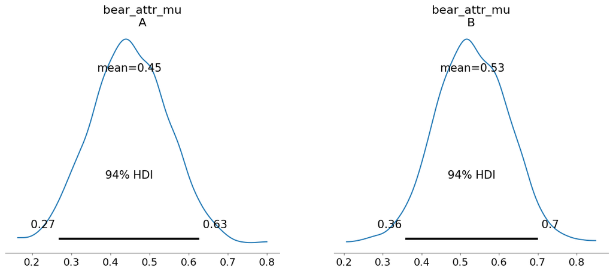

```python
import arviz as az

az.plot_posterior(trace);
```